# Identifying nests and swallows based on spatiotemporal wild boar data.

Project Works Patterns and Trends in Environmental Data

Yves Gubelmann and Tobias Wildhaber

4 July, 2021

# 1 Abstract

Due to the ongoing optimization of harvesting methods in agriculture, the prevention of wild boar damages has become increasingly popular in recent years. Understanding the selection of resting places like nests and wallows build the basis for effective management measures. Based on spatiotemporal data of wild boars we try to determine such resting places and allocate them to surrounding vegetation in ordert to differentiate them further into potential nesting and wallowing areas.

Based on literature data on the behaviour of wild boars and the analysis of movement patterns, we develop a robust method for the identification of potential nests and wallows.

The implementation of the modelling using the software R proves to be well feasible. The main challenges are the definition of clear criteria for the identification of nests and wallows, which the literature only provides to a limited extent, and the validation of the results.

# 2 Research Questions

Our research is based on data from the ZHAW research project “Prevention of Wild Boar Damage in Agriculture”(Suter et al., 2018). With this dataset as a basis, we want to answer the following research questions:

- How can resting sites be modeled based on spatiotemporal movement data?
- Can locations frequently visited by wild boar be determined efficiently and effectively in the provided research data?
- Can these regular resting places be clearly defined as nests or wallows?

# 3 Material and Methods

## 3.1 Data

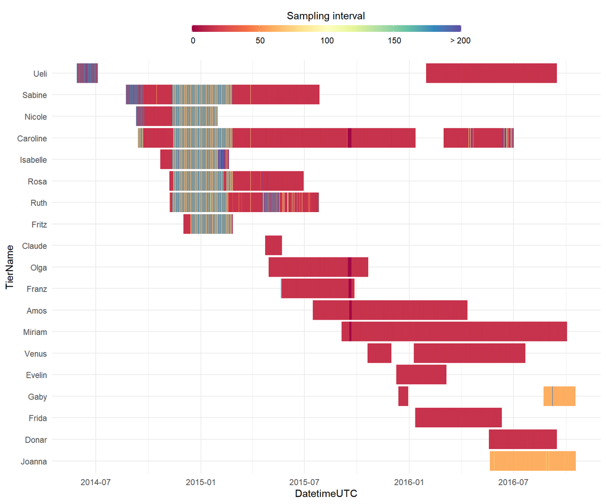

Figure 3.1: Sampling regime for all individuals in minutes

Furthermore we use spatial information about the vegetation to the spatiotemporal wild boar data. This data is provided by a survey which classified the investigated area in forests, wetlands, settlement and agriculture. If a lot of land was used for agriculture, information about the planted crop is also given. In total the survey evaluated 5154 lots of land, covering an area of 120 km^2. The evaluated area consists of 63 % agriculture, 22 % forest, 9 % settlement and 6 % wetlands (Suter & Eyholzer, 2010).

## 3.2 Analytical Concepts

In order to analyze the behavior of wild boars and to be able to distinguish between nests and wallows, the first step is to take a closer look at the trajectories, to filter and segment them (Laube & Purves, 2011).

The *steplength* is calculated based on the Euclidean distance, using the following formula:

$$\text{distance} = \sqrt{(\text{E1} - \text{E2})^{2}+(\text{N1} - \text{N2})^{2}}$$

Based on the calculated *steplength*, additional parameters such as *speed* and *timelag* are calculated. In a further step, the average distance within a given temporal window is calculated (*stepmean*) and then used to segment the wild boar data and to differentiate between resting and moving (*movement status*).

Since wild boars usually rest at nests and wallows the parameter movement status builds the basement for further analysis.

### 3.2.1 Wild Boar Behavior

Wild boars share a common movement pattern when spending time at wallows and nests: they stick to a location for a certain while and do not undertake wide distances during this time. Distinguishing this behavior from others builds the basement of our analytic concept. Wild boar biologists differentiate between the following wild boar behavior (Keuling & Stier, 2009):

- feeding
- protective behavior
- aggressive behavior
- comfort behavior
- other behavior (sleeping, resting, fleeing, strolling)

According to literature wild boar show some distinct behavioral patterns at nests and wallows:

#### 3.2.1.1 Nests

Multiple wild boars gather in close distance and stay there for an undefined while (Keuling & Stier, 2009). Since wild boars are nocturnal animals, they preferably rest in covered areas like forests or wetlands with high reeds.

During summertime agricultural fields with high crops like cereal (wheat, barley, oat etc.), rapeseed or corn can also provide a suitable nesting habitat. Surveys in this area showed that wild boars normally rest between 08:00 and 17:00 and revisit their nests up to eight times (Suter & Eyholzer, 2010).

#### 3.2.1.2 Wallows

Wild boars use wallows for hygiene purposes (Keuling & Stier, 2009). In a wallow the boars are able to regulate their body temperature since wild boars cannot sweat. This leads to the fact that wallowing happens mainly during summer season and is not observed before April (Fernández-Llario, 2005).

## 3.3 R Concepts

The analysis, visualization and documentation is conducted with the open-source software R, version 4.0.5 (R Core Team, 2021). The handling of spatiotemporal data is managed with the packages sf (Pebesma, 2018), terra (Hijmans, 2021) and raster (Hijmans, 2020a). The graphical representations ware created with ggplot2 (Wickham, 2016) as part of tidyverse (Wickham et al., 2019), which is also used for general data wrangling, alongside forcats (Wickham, 2021) to handle factor levels and janitor (Firke, 2021) for clean and consistent naming. Maps are generated using tmap (Tennekes, 2018) and leaflet (Cheng et al., 2021). The reports are generated by using knitr (Xie, 2014, 2015, 2021) and papeR (Hofner, 2021).

The wild boar data from the ZHAW research project (Suter et al., 2018) is provided in form of the separate R package ComputationalMovementAnalysis, version 0.1.14 (Ratnaweera, 2021).

### 3.3.1 Calculating Movement Parameters

In a preliminary phase we enrich the given data with important parameters for *Computational Movement Analysis*. For every data point we calculate *speed*, *steplength* and *timelag* to the next point.

Another movement parameter we add for our analysis is *stepmean*. It calculates the mean distance within a moving window of six data points. This variable allows us to apply segmentation on our wild boar data and define stops and moves (Variable *mov_status* with a two factors: *resting* or *moving*).

The mentioned movement parameter are implemented via the function *calc_movement_param*.

```r
calc_movement_param <- function(boar_dt) {
  boar_dt <- boar_dt %>%
    mutate(
      timelag = as.integer(difftime(lead(DatetimeUTC), DatetimeUTC, units = "secs")),
      steplength = sqrt(((E - lead(E, 1))^2 + (N - lead(N, 1))^2)),
      speed = steplength / timelag,
      nMinus3 = sqrt((lag(E, 3) - E)^2 + (lag(N, 3) - N)^2),
      nMinus2 = sqrt((lag(E, 2) - E)^2 + (lag(N, 2) - N)^2),
      nMinus1 = sqrt((lag(E, 1) - E)^2 + (lag(N, 1) - N)^2),
      nPlus1 = sqrt((E - lead(E, 1))^2 + (N - lead(N, 1))^2),
      nPlus2 = sqrt((E - lead(E, 2))^2 + (N - lead(N, 2))^2),
      nPlus3 = sqrt((E - lead(E, 3))^2 + (N - lead(N, 3))^2)
    ) %>%
    rowwise() %>%
    mutate(
      stepmean = mean(c(nMinus3, nMinus2, nMinus1, nPlus1, nPlus2, nPlus3)),
    ) %>%
    ungroup() %>%
    mutate(
      mov_static = if_else(stepmean < segment_trigger, TRUE, FALSE),
      mov_status = if_else(stepmean < segment_trigger, "resting", "moving"),
      cma_static = stepmean < mean(stepmean, na.rm = TRUE)
    )
  boar_dt
}
```

### 3.3.2 Filtering and Segmentation

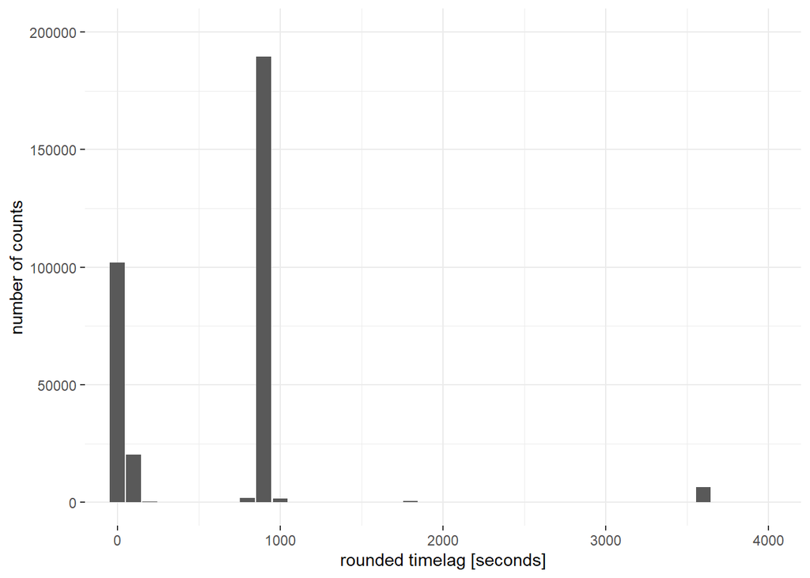

Figure 3.2: Distribution of timelag between two data points. A clear majority is sampled with a timelag of 900 seconds.

A clear distinction between *resting* and *moving* is done by the introduction of the variable *segment_trigger*. The appropriate level for this threshold is evaluated in a critical manner. We generate sample data sets from three different wild boars and evaluate them in a histogram. With a binwidth of 5, we are able to see a clear decline in the first bins of stepmean. This leads to our interpretation that wild boars rest on the left side of the histogram and move on the right side.

#### Ueli

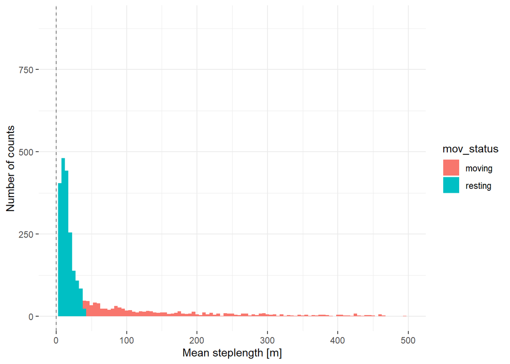

Figure 3.3: Mean steplength if wildboar Ueli. Sample dataset from May 2016. Threshold set to 40 meter.

#### Caroline

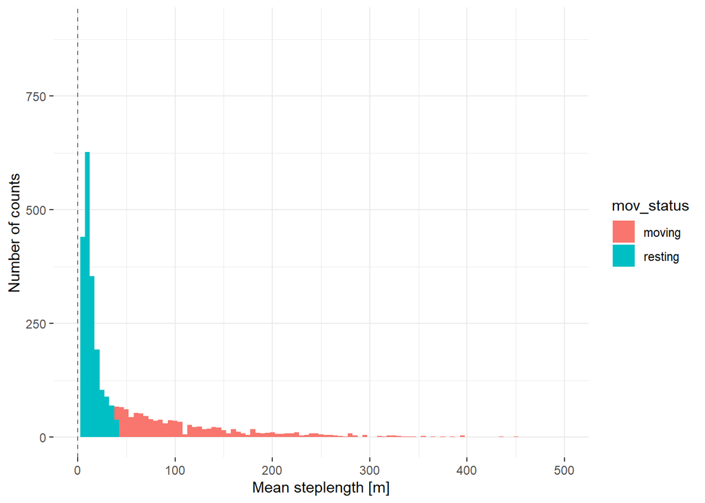

#### Frida

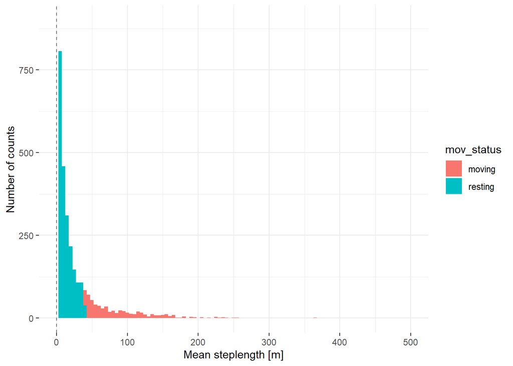

Setting the threshold seems reasonable at the point where *stepmean* flattens in a distinct manner (see histograms). In our samples this threshold can be anywhere between 30 to 50 meter. The *segment_trigger* is therefore set to 40. This leads to a division of the *movment status* into approximately 32 % resting and 68 % moving at the level of individual observations (fig. 3.6).

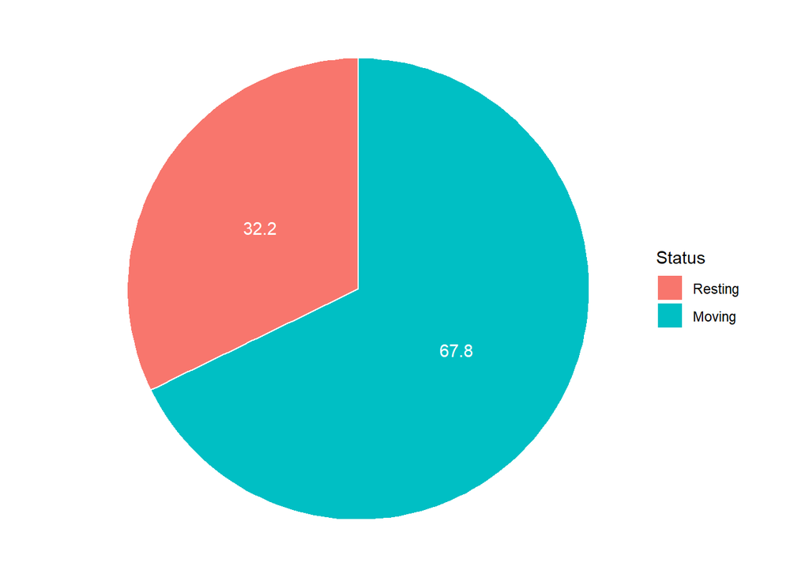

Figure 3.6: Pie chart of movement status at the level of individual observations

### 3.3.3 Adding Context

The vegetational information is joined with the wild boar observation to add spatial context which can then be used to further differentiate between potential nests and wallows based on literature information about circadian activity and preferred crop types.

```r
wildboar_lags <- wildboar_lags %>%
  # add wallow and nest criterias according to literature
  # enable line below if you want to filter all NAs in Frucht
  # filter(!is.na(Frucht)) %>%
  mutate(
    wallow_month = if_else(month > 3 & month < 10, TRUE, FALSE),
    wallow_day = case_when(
      day == "Abenddaemmerung" ~ FALSE,
      day == "Morgendaemmerung" ~ TRUE,
      day == "Nacht" ~ FALSE,
      day == "1Nachtviertel" ~ FALSE,
      day == "2Nachtviertel" ~ FALSE,
      day == "3Nachtviertel" ~ FALSE,
      day == "4Nachtviertel" ~ FALSE,
      day == "Tag" ~ TRUE,
      TRUE ~ NA # Default case
    ),
    wallow_area = case_when(
      Frucht == "Feuchtgebiet" ~ TRUE,
      Frucht == "Wald" ~ TRUE,
      Frucht == "Weizen" ~ FALSE,
      Frucht == "Gerste" ~ FALSE,
      Frucht == "Zwiebeln" ~ FALSE,
      Frucht == "Bohnen" ~ FALSE,
      Frucht == "Kartoffeln" ~ FALSE,
      Frucht == "Rueben" ~ FALSE,
      Frucht == "Chinaschilf" ~ FALSE,
      Frucht == "Mangold" ~ FALSE,
      Frucht == "Wiese" ~ FALSE,
      Frucht == "Kohlrabi" ~ FALSE,
      Frucht == "Weide" ~ FALSE,
      Frucht == "Lupinen" ~ FALSE,
      Frucht == "Flugplatz" ~ FALSE,
      Frucht == "Mais" ~ FALSE,
      Frucht == "Raps" ~ FALSE,
      Frucht == "Karotten" ~ FALSE,
      Frucht == "Acker" ~ FALSE,
      Frucht == "Sonnenblumen" ~ FALSE,
      Frucht == "Erbsen" ~ FALSE,
      Frucht == "Kohl" ~ FALSE,
      Frucht == "Hafer" ~ FALSE,
      Frucht == "Roggen" ~ FALSE,
      Frucht == "Salat" ~ FALSE,
      Frucht == "Rhabarber" ~ FALSE,
      Frucht == "Sellerie" ~ FALSE,
      Frucht == "Brache" ~ FALSE,
      Frucht == "Spargel" ~ FALSE,
      Frucht == "Obstplantage" ~ FALSE,
      Frucht == "Fenchel" ~ FALSE,
      Frucht == "Gemuese" ~ FALSE,
      Frucht == "Gewaechshaus" ~ FALSE,
      Frucht == "Zuchetti" ~ FALSE,
      Frucht == "Zucchetti" ~ FALSE,
      Frucht == "Flachs" ~ FALSE,
      Frucht == "Kuerbis" ~ FALSE,
      TRUE ~ NA # Default case
    ),
    nest_day = case_when(
      day == "Abenddaemmerung" ~ FALSE,
      day == "Morgendaemmerung" ~ FALSE,
      day == "Nacht" ~ FALSE,
      day == "1Nachtviertel" ~ FALSE,
      day == "2Nachtviertel" ~ FALSE,
      day == "3Nachtviertel" ~ FALSE,
      day == "4Nachtviertel" ~ FALSE,
      day == "Tag" ~ TRUE,
      TRUE ~ NA # Default case
    ),
    nest_summer_mon = if_else(month >= 5 & month <= 10, TRUE, FALSE),
    nest_winter_mon = if_else(month >= 5 & month <= 10, FALSE, TRUE),
    nest_summer_area = case_when(
      Frucht == "Feuchtgebiet" ~ FALSE,
      Frucht == "Wald" ~ TRUE,
      Frucht == "Weizen" ~ TRUE,
      Frucht == "Gerste" ~ TRUE,
      Frucht == "Zwiebeln" ~ FALSE,
      Frucht == "Bohnen" ~ FALSE,
      Frucht == "Kartoffeln" ~ FALSE,
      Frucht == "Rueben" ~ FALSE,
      Frucht == "Chinaschilf" ~ FALSE,
      Frucht == "Mangold" ~ FALSE,
      Frucht == "Wiese" ~ FALSE,
      Frucht == "Kohlrabi" ~ FALSE,
      Frucht == "Weide" ~ FALSE,
      Frucht == "Lupinen" ~ FALSE,
      Frucht == "Flugplatz" ~ FALSE,
      Frucht == "Mais" ~ TRUE,
      Frucht == "Raps" ~ TRUE,
      Frucht == "Karotten" ~ FALSE,
      Frucht == "Acker" ~ FALSE,
      Frucht == "Sonnenblumen" ~ FALSE,
      Frucht == "Erbsen" ~ FALSE,
      Frucht == "Kohl" ~ FALSE,
      Frucht == "Hafer" ~ TRUE,
      Frucht == "Roggen" ~ TRUE,
      Frucht == "Salat" ~ FALSE,
      Frucht == "Rhabarber" ~ FALSE,
      Frucht == "Sellerie" ~ FALSE,
      Frucht == "Brache" ~ FALSE,
      Frucht == "Spargel" ~ FALSE,
      Frucht == "Obstplantage" ~ FALSE,
      Frucht == "Fenchel" ~ FALSE,
      Frucht == "Gemuese" ~ FALSE,
      Frucht == "Gewaechshaus" ~ FALSE,
      Frucht == "Zuchetti" ~ FALSE,
      Frucht == "Zucchetti" ~ FALSE,
      Frucht == "Flachs" ~ FALSE,
      Frucht == "Kuerbis" ~ FALSE,
      TRUE ~ NA # Default case
    ),
    nest_winter_area = case_when(
      Frucht == "Feuchtgebiet" ~ TRUE,
      Frucht == "Wald" ~ TRUE,
      Frucht == "Weizen" ~ FALSE,
      Frucht == "Gerste" ~ FALSE,
      Frucht == "Zwiebeln" ~ FALSE,
      Frucht == "Bohnen" ~ FALSE,
      Frucht == "Kartoffeln" ~ FALSE,
      Frucht == "Rueben" ~ FALSE,
      Frucht == "Chinaschilf" ~ FALSE,
      Frucht == "Mangold" ~ FALSE,
      Frucht == "Wiese" ~ FALSE,
      Frucht == "Kohlrabi" ~ FALSE,
      Frucht == "Weide" ~ FALSE,
      Frucht == "Lupinen" ~ FALSE,
      Frucht == "Flugplatz" ~ FALSE,
      Frucht == "Mais" ~ FALSE,
      Frucht == "Raps" ~ FALSE,
      Frucht == "Karotten" ~ FALSE,
      Frucht == "Acker" ~ FALSE,
      Frucht == "Sonnenblumen" ~ FALSE,
      Frucht == "Erbsen" ~ FALSE,
      Frucht == "Kohl" ~ FALSE,
      Frucht == "Hafer" ~ FALSE,
      Frucht == "Roggen" ~ FALSE,
      Frucht == "Salat" ~ FALSE,
      Frucht == "Rhabarber" ~ FALSE,
      Frucht == "Sellerie" ~ FALSE,
      Frucht == "Brache" ~ FALSE,
      Frucht == "Spargel" ~ FALSE,
      Frucht == "Obstplantage" ~ FALSE,
      Frucht == "Fenchel" ~ FALSE,
      Frucht == "Gemuese" ~ FALSE,
      Frucht == "Gewaechshaus" ~ FALSE,
      Frucht == "Zuchetti" ~ FALSE,
      Frucht == "Zucchetti" ~ FALSE,
      Frucht == "Flachs" ~ FALSE,
      Frucht == "Kuerbis" ~ FALSE,
      TRUE ~ NA # Default case
    )
  )
```

### 3.3.4 Applying criteria for nests and wallows

After adding all the necessary convenience and context variables we are now able to apply the defined criteria to identify potential nests and wallows. In addition, we reduce the observations to one point per segment, while keeping the segment duration in a different variable (*segment_dur*) for further processing. The reason for this is that we only want to consider one count per segment in the final results, as the different lengths of the segments would otherwise lead to distorted representations. For example, according to literature and our applied definition, stays at wallows are much shorter than at nests, while the latter can vary greatly in duration.

```r
wildboar_lags <- wildboar_lags %>%
  group_by(segment_id) %>%
  mutate(segment_dur = n()) %>%
  filter(row_number(segment_id) == 1) %>%
  # keep first data point per segment only
  ungroup() %>%
  mutate(wallow_dur = if_else(segment_dur <= 3, TRUE, FALSE)) %>%
  filter(mov_status == "resting") %>%
  mutate(
    wallow = if_else(wallow_month & wallow_day & wallow_area & wallow_dur,
      TRUE, FALSE
    ),
    nest = if_else((nest_summer_mon & nest_day & nest_summer_area & segment_dur > 3) |
      (nest_winter_mon & nest_day & nest_winter_area & segment_dur > 3),
    TRUE, FALSE
    ),
    conflict = if_else(nest & wallow, TRUE, FALSE),
    site_type = as.factor(case_when(
      conflict == TRUE ~ "both",
      nest == TRUE ~ "nest",
      wallow == TRUE ~ "wallow",
      !wallow & !nest == TRUE ~ "none",
      TRUE ~ "NA" # Default case
    ))
  )
```

### 3.3.5 Visualizing Sample Data

To generate a visual representation of the newly filtered data, we create a sample subset with only three individuals (Caroline, Frida and Ueli) for the year 2016. The layers show potential nests and wallows, color-coded by the individuals. The two layers can be toggled on and off via the interactive map menu in the top right corner. Each point represents one segment while the size of the points corresponds to the segment duration. The map shows that there is some overlap between Caroline and Frida, while Ueli seems to prefer other areas.

The second tab shows a map of the the same data but without color-coding for the individuals. Here it is clearly visible that (for the chosen sample) potential nests and wallows are not found in clearly distinct areas.

#### Nests and Wallows

[interactive chart not shown]

#### Individuals

[interactive chart not shown]

### 3.3.6 **Rasterizing Data**

The last step to create a map of potential nests and wallows is to visualize the complete data. Since a vector-based map with around 6000 segments would be very confusing, a rasterized map is created instead. To do this, an empty grid is created with the raster package (Hijmans, 2020b) and then placed over the filtered data with the `raster::rasterize` command while applying the `count` function.

All generated raster maps are produced in two resolutions each: 100 m and 30 m. The reason for this is that 100 m corresponds to the area statistics of the federal government (Bundesamt für Statistik BFS, 2017) and thus to the publicly available data on land use (and thus vegetation). However, since the vegetation data from the ZHAW research project used here are of higher resolution, an additional representation with a 30 m grid is shown as well.

# 4 Results

The table below shows the applied criteria to differentiate between nests and wallows. Based on this selection, it is obvious that there is some overlap. Especially the vegetation as well as the time of day are in large parts identical. Differentiation takes place in particular on the basis of the duration of rest, with the threshold value being 45 minutes (which corresponds to a segment duration of 3).

Table 4.1: Applied criteria for nests and wallows

|  | Nests | Wallows |
| --- | --- | --- |
| **Movement** | resting | resting |
| **Month** | January to December | April to September |
| **Time of day** | day | day & dawn |
| **Vegetation** | forests & wetlands (winter) forests, cereal, corn & rapeseed (summer) | forests & wetlands |
| **Resting duration** | > 45 minutes | <= 45 minutes |

The application of these criteria on a segment level results in a division into approx. 16 % nests and 4 % wallows. 75 % of the segments do not fall into either category, 3.9 % are NA values (fig. 4.1).

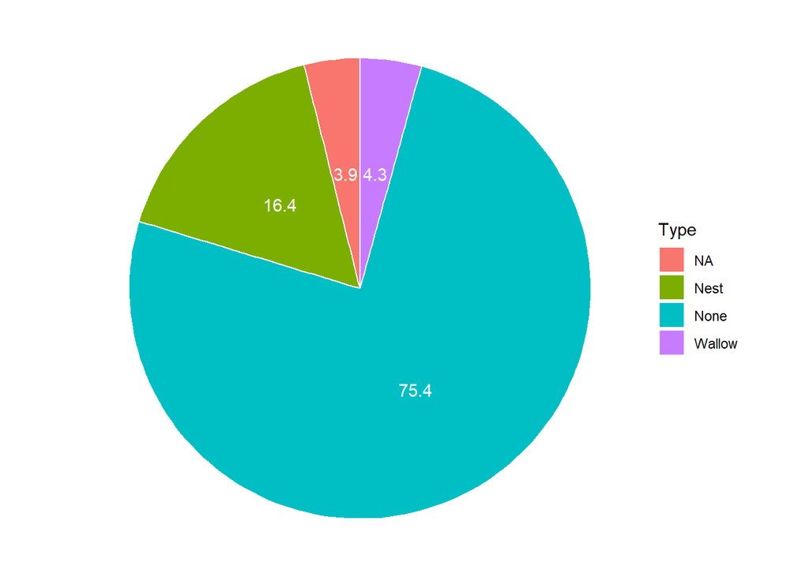

Figure 4.1: Pie chart of segment type by identity.

## 4.1 Resting Sites

A map of all the resting sites, meaning nests and wallows, shows that most raster cells are part of the lowest count category (0 to 50) segments. The highest concentration seems to be in the north-western part of the observed area near the lake in a wetland-area. This image becomes even clearer in the 30 m raster map (see second tab).

### 100 m Raster

[interactive chart not shown]

### 30 m Raster

[interactive chart not shown]

## 4.2 Nests and Wallows

The maps differentiated by nests and wallows confirm this concentration in the wetland for both types of use, although for wallows there appears to be another hot spot to the north in a wooded area. The overlapping, which has already been shown in the sample, is also recognizable here. To display only nests or wallows, the other layer can be hidden in the menu at the top right.

The higher resolution map shows a somewhat clearer differentiation between nests and wallows, although the picture of hot spots is also confirmed here and the most frequently visited sites are very close to each other. It should also be noted that the density of nests is much higher than that of wallows.

### 100 m Raster

[interactive chart not shown]

### 30 m Raster

[interactive chart not shown]

# 5 Discussion

The present project work shows one possible approach to model resting sites based on spatiotemporal movement data. With the calculation of a movement status we are able to distinguish between resting phases and moving phases. The threshold of this classification is based on sample datasets which we use for an simple assessment. Due to missing field data, this assessment method clearly lacks validation and introduces uncertainty in the following analysis. Nonetheless setting the threshold anywhere between 30 to 50 meter seems reasonable (see chapter 3.3.2).

The given research data provides a unique sampling regime with different timelags. With the aim to reduce complexity we only use trajectories with a timelag of 900 seconds. This results in a loss of 42.1 % of the provided dataset. On a first glance, a loss of 42.1 % seems like a critical amount. At a second look this can be justified since 31.2 % has an invalid timelag of zero seconds (Table 5.1. If one subtracts this portion, our analysis is able to assess roughly 84 % of all given trajectories which can be considered as effective. According to our research question the effectiveness is only considered for resting sites. Nonetheless it is worth mentioning that the effectiveness decreases rapidly when one looks at the final results of assigned nests and wallows. Only 20.7 % could be assigned to a nest or a wallow.

Table 5.1: Proportion of rounded timelags in provided dataset

| timelag_rounded | count | proportion |
| --- | --- | --- |
| 900 | 189611 | 57.9 |
| 0 | 102098 | 31.2 |
| 100 | 20394 | 6.2 |
| 3600 | 6560 | 2.0 |
| 10800 | 2585 | 0.8 |
| 800 | 1958 | 0.6 |
| 1000 | 1720 | 0.5 |
| 1800 | 561 | 0.2 |
| 200 | 309 | 0.1 |
| 3500 | 210 | 0.1 |
| 3700 | 208 | 0.1 |
| 1700 | 131 | 0.0 |
| 1900 | 152 | 0.0 |

The clear assignment of nests and wallows is the most challenging task. In our work we base our criteria for the assignment on a mix of analyzed movement trajectories and preferred habitat use which we derived from literature. We are able to assign 16.4 % of all resting sites to nests, 4.3 % to wallows. The fact that the assigned number of nests is four times higher than wallows seems valid. Wild boars spend more time with basic needs than comfort behavior like wallowing (Keuling & Stier, 2009).

Furthermore it seems valid that about 75 % is not assigned to a nest or wallow since the criteria (month, day and area) are logically AND-linked. When an evaluation of the processed data is done, it becomes clear that the daytime alone already has a big impact on the assignment. For nests and wallows, about two thirds of all segments are not suitable as a resting site (see *net_day* and *wallow_day* in Table 5.2).

A small proportion of all resting sites are assigned with NA. A quick traceback in the data reveals that this is clearly caused by missing field information (see *wallow_area* in Table 5.2). The same number of NAs applies for *nest_summer_area* and *nest_winter_area*.

Table 5.2: Summary table for the daytime variables for nests and wallows and the area variable for wallows.

|  | Level |  | N | % |
| --- | --- | --- | --- | --- |
| nest_day | FALSE |  | 4033 | 68.0 |
|  | TRUE |  | 1901 | 32.0 |
| wallow_day | FALSE |  | 3879 | 65.4 |
|  | TRUE |  | 2055 | 34.6 |
| wallow_area | FALSE |  | 1362 | 23.0 |
|  | NA |  | 821 | 13.8 |
|  | TRUE |  | 3751 | 63.2 |

A closer interpretation of the processed data shows that we are able to assign nests and wallows to potential resting sites. It is also clear that using logical AND-links tend to provide results with a rather conservative interpretation. Another – underlying – uncertainty is the threshold which distinguishes between moving and resting trajectories. This threshold and all results lack clearly of validation. It remains unclear whether a wallow is assigned correctly and could not be, for instance, a feeding location. In that sense, our results show a distribution of potential nests and wallows. Further research would have to prove the effectiveness of the developed method.

Apart from the stated uncertainties, we are confident that we have developed a robust method for the assignment of resting sites. Nevertheless, the developed method requires fine tuning and a validation of the results.

## 5.1 Risk analysis and Problems

As stated in our proposal, it is difficult to find reliant literature about wild boar behavior at nests and wallows. The literature information we applied in this work helps us to filter potential sites in a fair way. Nonetheless the provided information is often formulated too broad or then overlapping. This means that an assignment of potential sites is possible but a differentiation between nest and wallow remains impossible. Only thanks to an elaborate survey on the same area it is possible to implement a functional assignment (Suter & Eyholzer, 2010).

A remaining issue is the lack of validation. It is clear that the meaning of a serious validation cannot be underestimated and is essential in environmental research (Rykiel Jr, 1996). Since no validation data is provided, no statement about the validity and effectiveness of our method is possible.

# 6 References

Bundesamt für Statistik BFS. (2017). *Arealstatistik nach nomenklatur 2004 standard*.

Cheng, J., Karambelkar, B., & Xie, Y. (2021). *Leaflet: Create interactive web maps with the JavaScript ’leaflet’ library*. https://CRAN.R-project.org/package=leaflet

Fernández-Llario, P. (2005). The sexual function of wallowing in male wild boar (sus scrofa). *Journal of Ethology*, *23*(1), 914.

Firke, S. (2021). *Janitor: Simple tools for examining and cleaning dirty data*. https://CRAN.R-project.org/package=janitor

Hijmans, R. J. (2020a). *Raster: Geographic data analysis and modeling*. https://CRAN.R-project.org/package=raster

Hijmans, R. J. (2020b). *Raster: Geographic data analysis and modeling*. https://CRAN.R-project.org/package=raster

Hijmans, R. J. (2021). *Terra: Spatial data analysis*. https://CRAN.R-project.org/package=terra

Hofner, B. (2021). *papeR: A toolbox for writing pretty papers and reports*. https://CRAN.R-project.org/package=papeR

Keuling, O., & Stier, N. (2009). *Schwarzwild - untersuchungen zu raum- und habitatnutzung des schwarzwildes (sus scrofa l. 1758) in südwest-mecklenburg unter besonderer berücksichtigung des bejagungseinflusses und der rolle älterer stücke in den rotten*. https://doi.org/10.13140/RG.2.1.1543.7520

Laube, P., & Purves, R. S. (2011). How fast is a cow? Cross-Scale Analysis of Movement Data: Cross-Scale Trajectory Analysis. *Transactions in GIS*, *15*(3), 401–418. https://doi.org/10.1111/j.1467-9671.2011.01256.x

Meynhardt, H. (1990). *Schwarzwild-report*.

Pebesma, E. (2018). Simple features for r: Standardized support for spatial vector data. *The R Journal*, *10*(1), 439446. https://doi.org/10.32614/RJ-2018-009

R Core Team. (2021). *R: A language and environment for statistical computing*. R Foundation for Statistical Computing. https://www.R-project.org/

Ratnaweera, N. (2021). *ComputationalMovementAnalysisData: Provides data to use in the course ComputationalMovementAnalysis*. https://computationalmovementanalysis.github.io/ComputationalMovementAnalysisData/

Rykiel Jr, E. J. (1996). Testing ecological models: The meaning of validation. *Ecological Modelling*, *90*(3), 229244.

Suter, S., & Eyholzer, R. (2010). *Interkantonales wildschweinprojekt FR-BE-VD, räumliche und zeitliche habitatnutzung, schäden an landwirtschaftlichen kulturen und einfluss der jagd auf das raumverhalten der wildschweine am südostufer des neuenburgersees*.

Suter, S., Stoller, S., & Sigrist, B. (2018). *Prävention von wildschweinschäden in der landwirtschaft und management von wildschweinen in schutzgebieten. schlussbericht.*

Tennekes, M. (2018). Tmap: Thematic maps in r. *Journal of Statistical Software*, *84*(6), 139. https://doi.org/10.18637/jss.v084.i06

Vectronic Aerospace. (2021). *VERTEX PLUS collars*. https://www.vectronic-aerospace.com/vertex-plus-collar/

Wickham, H. (2016). *ggplot2: Elegant graphics for data analysis*. Springer-Verlag New York. https://ggplot2.tidyverse.org

Wickham, H. (2021). *Forcats: Tools for working with categorical variables (factors)*. https://CRAN.R-project.org/package=forcats

Wickham, H., Averick, M., Bryan, J., Chang, W., McGowan, L. D., François, R., Grolemund, G., Hayes, A., Henry, L., Hester, J., Kuhn, M., Pedersen, T. L., Miller, E., Bache, S. M., Müller, K., Ooms, J., Robinson, D., Seidel, D. P., Spinu, V., … Yutani, H. (2019). Welcome to the tidyverse. *Journal of Open Source Software*, *4*(43), 1686. https://doi.org/10.21105/joss.01686

Xie, Y. (2014). *Knitr: A comprehensive tool for reproducible research in r* (V. Stodden, F. Leisch, & R. D. Peng, Eds.). Chapman; Hall/CRC. http://www.crcpress.com/product/isbn/9781466561595

Xie, Y. (2015). *Dynamic documents with r and knitr* (2nd ed.). Chapman; Hall/CRC. https://yihui.org/knitr/

Xie, Y. (2021). *Knitr: A general-purpose package for dynamic report generation in r*. https://yihui.org/knitr/

# 7 Appendix

## Complete R Script

```r
# libraries ---------------------------------------------------------------

# install package with wildobar data:
# devtools::install_github("ComputationalMovementAnalysis/ComputationalMovementAnalysisData")

library(papeR) # summary tables
library(tidyverse) # tidy essentials (ggplot, purr, tidyr, readr, dplyr)
library(lubridate) # handling dates and time
library(tmap) # map visualization
library(leaflet) # interactive maps
library(terra) # handling spatial data
library(ComputationalMovementAnalysisData) # wild boar data
library(sf) # handling spatial data
library(janitor) # clean and consistent naming
library(forcats) # handling factor levels
library(raster) # rasterizing vector data
library(knitr) # for pretty tables


# globals ----------------------------------------------------------------------

# threshold that triggers the segmentation of the movement trajectory
segment_trigger <- 40

# functions ---------------------------------------------------------------

calc_movement_param <- function(boar_dt) {
  boar_dt <- boar_dt %>%
    mutate(
      timelag = as.integer(difftime(lead(DatetimeUTC), DatetimeUTC, units = "secs")),
      steplength = sqrt(((E - lead(E, 1))^2 + (N - lead(N, 1))^2)),
      speed = steplength / timelag,
      nMinus3 = sqrt((lag(E, 3) - E)^2 + (lag(N, 3) - N)^2),
      nMinus2 = sqrt((lag(E, 2) - E)^2 + (lag(N, 2) - N)^2),
      nMinus1 = sqrt((lag(E, 1) - E)^2 + (lag(N, 1) - N)^2),
      nPlus1 = sqrt((E - lead(E, 1))^2 + (N - lead(N, 1))^2),
      nPlus2 = sqrt((E - lead(E, 2))^2 + (N - lead(N, 2))^2),
      nPlus3 = sqrt((E - lead(E, 3))^2 + (N - lead(N, 3))^2)
    ) %>%
    rowwise() %>%
    mutate(
      stepmean = mean(c(nMinus3, nMinus2, nMinus1, nPlus1, nPlus2, nPlus3)),
    ) %>%
    ungroup() %>%
    mutate(
      mov_static = if_else(stepmean < segment_trigger, TRUE, FALSE),
      mov_status = if_else(stepmean < segment_trigger, "resting", "moving"),
      cma_static = stepmean < mean(stepmean, na.rm = TRUE)
    )
  boar_dt
}

rle_id <- function(vec) {
  x <- rle(vec)$lengths
  as.factor(rep(seq_along(x), times = x))
}

# data import -------------------------------------------------------------

wildboar_raw <- wildschwein_BE
head(wildboar_raw)

wildboar_meta <- wildschwein_metadata
head(wildboar_meta)
# ?wildschwein_metadata

wildboar_overlap <- wildschwein_overlap_temp
head(wildboar_overlap)
# ?wildschwein_overlap_temp

# import feldaufnahmen
feldaufnahmen <- read_sf("data/Feldaufnahmen_Fanel.gpkg")

# add geometry and time ---------------------------------------------------------

# argument remove = False keeps the coordinates E and N
wildboar_sf <- st_as_sf(wildboar_raw, coords = c("E", "N"), crs = 2056, remove = FALSE)
# join feldaufnahmen with wildboar data
wildboar_sf <- st_join(x = wildboar_sf, y = feldaufnahmen)
# add time
wildboar_sf <- wildboar_sf %>%
  mutate(
    month = month(DatetimeUTC),
    year = year(DatetimeUTC)
  )

# time lags ---------------------------------------------------------

# replace wildboar_raw by wildboar_sf for spatial information
wildboar_lags <- wildboar_sf %>%
  group_by(TierID) %>%
  mutate(timelag = as.integer(difftime(lead(DatetimeUTC), DatetimeUTC), units = "secs"))

# round lags on -2 digits
wildboar_lags$timelag_rounded <- round(wildboar_lags$timelag, -2)

# build categories with rounded lags
wildboar_lag_cat <- wildboar_lags %>%
  st_drop_geometry() %>%
  group_by(timelag_rounded) %>%
  summarise(count = n()) %>%
  mutate(
    proportion = count / sum(count) * 100,
    proportion = round(proportion, 1)
  ) %>%
  arrange(desc(proportion))

wildboar_lag_cat


# preprocessing ---------------------------------------------------------

# assign convenience variables for step 6
wildboar_lags <- wildboar_lags %>%
  # add wallow and nest criterias according to literature
  # enable line below if you want to filter all NAs in Frucht
  # filter(!is.na(Frucht)) %>%
  mutate(
    wallow_month = if_else(month > 3 & month < 10, TRUE, FALSE),
    wallow_day = case_when(
      day == "Abenddaemmerung" ~ FALSE,
      day == "Morgendaemmerung" ~ TRUE,
      day == "Nacht" ~ FALSE,
      day == "1Nachtviertel" ~ FALSE,
      day == "2Nachtviertel" ~ FALSE,
      day == "3Nachtviertel" ~ FALSE,
      day == "4Nachtviertel" ~ FALSE,
      day == "Tag" ~ TRUE,
      TRUE ~ NA # Default case
    ),
    wallow_area = case_when(
      Frucht == "Feuchtgebiet" ~ TRUE,
      Frucht == "Wald" ~ TRUE,
      Frucht == "Weizen" ~ FALSE,
      Frucht == "Gerste" ~ FALSE,
      Frucht == "Zwiebeln" ~ FALSE,
      Frucht == "Bohnen" ~ FALSE,
      Frucht == "Kartoffeln" ~ FALSE,
      Frucht == "Rueben" ~ FALSE,
      Frucht == "Chinaschilf" ~ FALSE,
      Frucht == "Mangold" ~ FALSE,
      Frucht == "Wiese" ~ FALSE,
      Frucht == "Kohlrabi" ~ FALSE,
      Frucht == "Weide" ~ FALSE,
      Frucht == "Lupinen" ~ FALSE,
      Frucht == "Flugplatz" ~ FALSE,
      Frucht == "Mais" ~ FALSE,
      Frucht == "Raps" ~ FALSE,
      Frucht == "Karotten" ~ FALSE,
      Frucht == "Acker" ~ FALSE,
      Frucht == "Sonnenblumen" ~ FALSE,
      Frucht == "Erbsen" ~ FALSE,
      Frucht == "Kohl" ~ FALSE,
      Frucht == "Hafer" ~ FALSE,
      Frucht == "Roggen" ~ FALSE,
      Frucht == "Salat" ~ FALSE,
      Frucht == "Rhabarber" ~ FALSE,
      Frucht == "Sellerie" ~ FALSE,
      Frucht == "Brache" ~ FALSE,
      Frucht == "Spargel" ~ FALSE,
      Frucht == "Obstplantage" ~ FALSE,
      Frucht == "Fenchel" ~ FALSE,
      Frucht == "Gemuese" ~ FALSE,
      Frucht == "Gewaechshaus" ~ FALSE,
      Frucht == "Zuchetti" ~ FALSE,
      Frucht == "Zucchetti" ~ FALSE,
      Frucht == "Flachs" ~ FALSE,
      Frucht == "Kuerbis" ~ FALSE,
      TRUE ~ NA # Default case
    ),
    nest_day = case_when(
      day == "Abenddaemmerung" ~ FALSE,
      day == "Morgendaemmerung" ~ FALSE,
      day == "Nacht" ~ FALSE,
      day == "1Nachtviertel" ~ FALSE,
      day == "2Nachtviertel" ~ FALSE,
      day == "3Nachtviertel" ~ FALSE,
      day == "4Nachtviertel" ~ FALSE,
      day == "Tag" ~ TRUE,
      TRUE ~ NA # Default case
    ),
    nest_summer_mon = if_else(month >= 5 & month <= 10, TRUE, FALSE),
    nest_winter_mon = if_else(month >= 5 & month <= 10, FALSE, TRUE),
    nest_summer_area = case_when(
      Frucht == "Feuchtgebiet" ~ FALSE,
      Frucht == "Wald" ~ TRUE,
      Frucht == "Weizen" ~ TRUE,
      Frucht == "Gerste" ~ TRUE,
      Frucht == "Zwiebeln" ~ FALSE,
      Frucht == "Bohnen" ~ FALSE,
      Frucht == "Kartoffeln" ~ FALSE,
      Frucht == "Rueben" ~ FALSE,
      Frucht == "Chinaschilf" ~ FALSE,
      Frucht == "Mangold" ~ FALSE,
      Frucht == "Wiese" ~ FALSE,
      Frucht == "Kohlrabi" ~ FALSE,
      Frucht == "Weide" ~ FALSE,
      Frucht == "Lupinen" ~ FALSE,
      Frucht == "Flugplatz" ~ FALSE,
      Frucht == "Mais" ~ TRUE,
      Frucht == "Raps" ~ TRUE,
      Frucht == "Karotten" ~ FALSE,
      Frucht == "Acker" ~ FALSE,
      Frucht == "Sonnenblumen" ~ FALSE,
      Frucht == "Erbsen" ~ FALSE,
      Frucht == "Kohl" ~ FALSE,
      Frucht == "Hafer" ~ TRUE,
      Frucht == "Roggen" ~ TRUE,
      Frucht == "Salat" ~ FALSE,
      Frucht == "Rhabarber" ~ FALSE,
      Frucht == "Sellerie" ~ FALSE,
      Frucht == "Brache" ~ FALSE,
      Frucht == "Spargel" ~ FALSE,
      Frucht == "Obstplantage" ~ FALSE,
      Frucht == "Fenchel" ~ FALSE,
      Frucht == "Gemuese" ~ FALSE,
      Frucht == "Gewaechshaus" ~ FALSE,
      Frucht == "Zuchetti" ~ FALSE,
      Frucht == "Zucchetti" ~ FALSE,
      Frucht == "Flachs" ~ FALSE,
      Frucht == "Kuerbis" ~ FALSE,
      TRUE ~ NA # Default case
    ),
    nest_winter_area = case_when(
      Frucht == "Feuchtgebiet" ~ TRUE,
      Frucht == "Wald" ~ TRUE,
      Frucht == "Weizen" ~ FALSE,
      Frucht == "Gerste" ~ FALSE,
      Frucht == "Zwiebeln" ~ FALSE,
      Frucht == "Bohnen" ~ FALSE,
      Frucht == "Kartoffeln" ~ FALSE,
      Frucht == "Rueben" ~ FALSE,
      Frucht == "Chinaschilf" ~ FALSE,
      Frucht == "Mangold" ~ FALSE,
      Frucht == "Wiese" ~ FALSE,
      Frucht == "Kohlrabi" ~ FALSE,
      Frucht == "Weide" ~ FALSE,
      Frucht == "Lupinen" ~ FALSE,
      Frucht == "Flugplatz" ~ FALSE,
      Frucht == "Mais" ~ FALSE,
      Frucht == "Raps" ~ FALSE,
      Frucht == "Karotten" ~ FALSE,
      Frucht == "Acker" ~ FALSE,
      Frucht == "Sonnenblumen" ~ FALSE,
      Frucht == "Erbsen" ~ FALSE,
      Frucht == "Kohl" ~ FALSE,
      Frucht == "Hafer" ~ FALSE,
      Frucht == "Roggen" ~ FALSE,
      Frucht == "Salat" ~ FALSE,
      Frucht == "Rhabarber" ~ FALSE,
      Frucht == "Sellerie" ~ FALSE,
      Frucht == "Brache" ~ FALSE,
      Frucht == "Spargel" ~ FALSE,
      Frucht == "Obstplantage" ~ FALSE,
      Frucht == "Fenchel" ~ FALSE,
      Frucht == "Gemuese" ~ FALSE,
      Frucht == "Gewaechshaus" ~ FALSE,
      Frucht == "Zuchetti" ~ FALSE,
      Frucht == "Zucchetti" ~ FALSE,
      Frucht == "Flachs" ~ FALSE,
      Frucht == "Kuerbis" ~ FALSE,
      TRUE ~ NA # Default case
    )
  )
```

```r
# This checks a certain variable for NAs
# na_check <- wildboar_lags %>%
#   filter(is.na(wallow_area))

wildboar_lags <- calc_movement_param(wildboar_lags)
wildboar_lags <- wildboar_lags %>%
  # run segment-based analysis with rle_id. copied from cma_week 3
  # choose between: own threshold (mov_static) or from cma_week 3 (cma_static)
  mutate(segment_id = rle_id(mov_static)) %>%
  # select only rows with an certain timelag
  # if no filter is applied, sequencing creates misleading results
  filter(timelag_rounded == 900)

# visualize movement status --------------------------------------------------

summary(as.factor(wildboar_lags$mov_status))

mov_status <- data.frame(summary(as.factor(wildboar_lags$mov_status))) %>%
  rename(count = 1) %>%
  slice(-3) %>%
  rownames_to_column(var = "status") %>%
  mutate(
    prop = count / sum(count) * 100,
    prop = round(prop, 1)
  ) %>%
  arrange(desc(status)) %>%
  mutate(lab.ypos = cumsum(prop) - 0.5 * prop)

pie <- ggplot(mov_status, aes(x = "", y = prop, fill = status)) +
  geom_bar(width = 1, stat = "identity", color = "white") +
  coord_polar("y", start = 0) +
  geom_text(aes(y = lab.ypos, label = prop), color = "white") +
  scale_fill_discrete(name = "Status", labels = c("Resting", "Moving")) +
  theme_void()

pie

# cross-scale movement analysis ####
seq3 <- seq(from = 1, to = nrow(wildboar_raw), by = 3)
seq6 <- seq(from = 1, to = nrow(wildboar_raw), by = 6)
seq9 <- seq(from = 1, to = nrow(wildboar_raw), by = 9)

# sample data -------------------------------------------------------------

# create a sample of caroline
caro <- wildboar_sf %>%
  filter(
    year == 2015,
    month == 5,
    TierName == "Caroline"
  )

# create a sample of Frida
frida <- wildboar_sf %>%
  filter(
    year == 2016,
    month == 5,
    TierName == "Frida"
  )

# create a sample of Ueli
ueli <- wildboar_sf %>%
  filter(
    year == 2016,
    month == 5,
    TierName == "Ueli"
  )

# for sample data
caro_seq3 <- seq(from = 1, to = nrow(caro), by = 3)
caro_seq6 <- seq(from = 1, to = nrow(caro), by = 6)
frida_seq3 <- seq(from = 1, to = nrow(frida), by = 3)
frida_seq6 <- seq(from = 1, to = nrow(frida), by = 6)
ueli_seq3 <- seq(from = 1, to = nrow(ueli), by = 3)
ueli_seq6 <- seq(from = 1, to = nrow(ueli), by = 6)
caro_3 <- caro %>% slice(caro_seq3)
caro_6 <- caro %>% slice(caro_seq6)
frida_3 <- frida %>% slice(frida_seq3)
frida_6 <- frida %>% slice(frida_seq6)
ueli_3 <- ueli %>% slice(ueli_seq3)
ueli_6 <- ueli %>% slice(ueli_seq6)


# calculate speed, steplength and timelag for sample data ####

# for sample data, for wildboar_lags its already done
caro <- calc_movement_param(caro)
caro_3 <- calc_movement_param(caro_3)
caro_6 <- calc_movement_param(caro_6)
frida <- calc_movement_param(frida)
frida_3 <- calc_movement_param(frida_3)
frida_6 <- calc_movement_param(frida_6)
ueli <- calc_movement_param(ueli)
ueli_3 <- calc_movement_param(ueli_3)
ueli_6 <- calc_movement_param(ueli_6)


# plot mean steplength for sample data ####

stepmean_ueli <- ggplot(ueli, aes(x = stepmean, fill = mov_status))
stepmean_ueli <- stepmean_ueli + geom_histogram(binwidth = 5) +
  scale_x_continuous(limits = c(0, 500)) +
  scale_y_continuous(limits = c(0, 900)) +
  geom_vline(xintercept = 0, lty = 2, alpha = 0.5) +
  theme_bw() +
  theme(panel.border = element_blank()) +
  labs(
    x = "Mean steplength [m]",
    y = "Number of counts"
  )

stepmean_ueli

stepmean_caro <- ggplot(caro, aes(x = stepmean, fill = mov_status))
stepmean_caro <- stepmean_caro + geom_histogram(binwidth = 5) +
  scale_x_continuous(limits = c(0, 500)) +
  scale_y_continuous(limits = c(0, 900)) +
  geom_vline(xintercept = 0, lty = 2, alpha = 0.5) +
  theme_bw() +
  theme(panel.border = element_blank()) +
  labs(
    x = "Mean steplength [m]",
    y = "Number of counts"
  )

stepmean_caro

stepmean_frida <- ggplot(frida, aes(x = stepmean, fill = mov_status))
stepmean_frida <- stepmean_frida + geom_histogram(binwidth = 5) +
  scale_x_continuous(limits = c(0, 500)) +
  scale_y_continuous(limits = c(0, 900)) +
  geom_vline(xintercept = 0, lty = 2, alpha = 0.5) +
  theme_bw() +
  theme(panel.border = element_blank()) +
  labs(
    x = "Mean steplength [m]",
    y = "Number of counts"
  )

stepmean_frida

# assign movement status and apply criterias -----------------

# for all data

wildboar_lags <- wildboar_lags %>%
  group_by(segment_id) %>%
  mutate(segment_dur = n()) %>%
  filter(row_number(segment_id) == 1) %>%
  # keep only the first data point per segment
  ungroup() %>%
  mutate(wallow_dur = if_else(segment_dur <= 3, TRUE, FALSE)) %>%
  filter(mov_status == "resting") %>%
  mutate(
    wallow = if_else(wallow_month & wallow_day & wallow_area & wallow_dur,
      TRUE, FALSE
    ),
    nest = if_else((nest_summer_mon & nest_day & nest_summer_area & segment_dur > 3) |
      (nest_winter_mon & nest_day & nest_winter_area & segment_dur > 3),
    TRUE, FALSE
    ),
    conflict = if_else(nest & wallow, TRUE, FALSE),
    site_type = as.factor(case_when(
      conflict == TRUE ~ "both",
      nest == TRUE ~ "nest",
      wallow == TRUE ~ "wallow",
      !wallow & !nest == TRUE ~ "none",
      TRUE ~ "NA" # Default case
    ))
  )


# check the dataset (number of wallows, nests, NAs etc)

summary(wildboar_lags)

# create pie chart for site_type ####

site_type <- data.frame(summary(wildboar_lags$site_type)) %>%
  rename(count = 1) %>%
  rownames_to_column(var = "type") %>%
  mutate(
    prop = count / sum(count) * 100,
    prop = round(prop, 1)
  ) %>%
  arrange(desc(type)) %>%
  mutate(lab.ypos = cumsum(prop) - 0.5 * prop)

pie <- ggplot(site_type, aes(x = "", y = prop, fill = type)) +
  geom_bar(width = 1, stat = "identity", color = "white") +
  coord_polar("y", start = 0) +
  geom_text(aes(y = lab.ypos, label = prop), color = "white") +
  scale_fill_discrete(name = "Type", labels = c("NA", "Nest", "None", "Wallow")) +
  theme_void()

pie


# plot sample data -------------------------------------------------------

# generate new samples from wildboar_lags data
```

```r
ueli_filter <- wildboar_lags %>%
  filter(
    year == 2016,
    # month == 5,
    site_type == "wallow" | site_type == "nest",
    TierName == "Ueli"
  ) %>%
  mutate(site_type = droplevels(site_type))

frida_filter <- wildboar_lags %>%
  filter(
    year == 2016,
    # month == 5,
    site_type == "wallow" | site_type == "nest",
    TierName == "Frida"
  ) %>%
  mutate(site_type = droplevels(site_type))

caro_filter <- wildboar_lags %>%
  filter(
    year == 2016,
    # month == 5,
    site_type == "wallow" | site_type == "nest",
    TierName == "Caroline"
  ) %>%
  mutate(site_type = droplevels(site_type))

wallows_sample <- wildboar_lags %>%
  filter(
    year == 2016,
    # month == 5,
    site_type == "wallow",
    TierName == "Caroline" | TierName == "Ueli" | TierName == "Frida"
  ) %>%
  mutate(site_type = droplevels(site_type))

nests_sample <- wildboar_lags %>%
  filter(
    year == 2016,
    # month == 5,
    site_type == "nest",
    TierName == "Caroline" | TierName == "Ueli" | TierName == "Frida"
  ) %>%
  mutate(site_type = droplevels(site_type))

# Polt interactive map with sample animals ####

# one layer per animal

# tmaptools::palette_explorer()

oranges <- tmaptools::get_brewer_pal("Oranges", n = 3, contrast = c(0.1, 0.9))
purples <- tmaptools::get_brewer_pal("Purples", n = 3, contrast = c(0.1, 0.9))

viridis <- viridisLite::viridis(3, begin = 0.23, end = 0.78)
magma <- viridisLite::magma(3, begin = 0.23, end = 0.78)

dark2 <- tmaptools::get_brewer_pal("Dark2", n = 6)
dark_n <- dark2[1:3]
dark_w <- dark2[4:6]

tm_animals <-
  tmap_mode("view") +
  tm_shape(ueli_filter) +
  tm_symbols(
    col = "site_type", size = "segment_dur", alpha = 0.5, title.col = "Ueli",
    palette = c("orange", "purple"), size.lim = c(1, 10)
  ) +
  tm_shape(frida_filter) +
  tm_symbols(
    col = "site_type", size = "segment_dur", alpha = 0.5, title.col = "Frida",
    palette = c("orange", "purple"), size.lim = c(1, 10)
  ) +
  tm_shape(caro_filter) +
  tm_symbols(
    col = "site_type", size = "segment_dur", alpha = 0.5, title.col = "Caroline",
    palette = c("orange", "purple"), size.lim = c(1, 10)
  ) +
  tm_view(control.position = c("right", "top"))

tm_animals

# one layer per field type (nests and wallos only)

tm_sample <-
  tmap_mode("view") +
  tm_shape(nests_sample) +
  tm_symbols(
    col = "TierName", size = "segment_dur", alpha = 0.5, title.col = "Nests",
    palette = magma, size.lim = c(1, 10)
  ) +
  tm_shape(wallows_sample) +
  tm_symbols(
    col = "TierName", size = "segment_dur", alpha = 0.5, title.col = "Wallows",
    palette = viridis, size.lim = c(1, 10)
  ) +
  tm_view(control.position = c("right", "top"))

tm_sample

# rasterize data ----------------------------------------------------------

# generate a raster-template with a resolution of 30 m (analog to steplength threshold)
raster_100 <- raster(extent(wildboar_lags), resolution = 100, crs = 2056)
raster_30 <- raster(extent(wildboar_lags), resolution = 30, crs = 2056)

# filter resting, with only the first data point of each segment_id

resting <- wildboar_lags # %>%
#  group_by(segment_id) %>%
#  filter(row_number(segment_id) == 1)

# filter wallows and Nests filtern for seperate layers

wallows <- wildboar_lags %>%
  filter(wallow == "TRUE") # %>%
#  group_by(segment_id) %>%
#  filter(row_number(segment_id) == 1)

nests <- wildboar_lags %>%
  filter(nest == "TRUE") # %>%
#  group_by(segment_id) %>%
#  filter(row_number(segment_id) == 1)

# rasterize data

# rasterize layers

resting_raster_100 <- raster::rasterize(resting, raster_100, field = 1, fun = "count")
wallows_raster_100 <- raster::rasterize(wallows, raster_100, field = 1, fun = "count")
nests_raster_100 <- raster::rasterize(nests, raster_100, field = 1, fun = "count")

resting_raster_30 <- raster::rasterize(resting, raster_30, field = 1, fun = "count")
wallows_raster_30 <- raster::rasterize(wallows, raster_30, field = 1, fun = "count")
nests_raster_30 <- raster::rasterize(nests, raster_30, field = 1, fun = "count")

# plots

greens <- tmaptools::get_brewer_pal("Greens", n = 6, contrast = c(0.3, 0.9))
oranges <- tmaptools::get_brewer_pal("Oranges", n = 5, contrast = c(0.3, 0.9))
purples <- tmaptools::get_brewer_pal("Purples", n = 5, contrast = c(0.3, 0.9))

# resolution: 100 m

tm_r_100 <-
  tmap_mode("view") +
  tm_shape(resting_raster_100) +
  tm_raster(palette = greens, title = "Resting sites", alpha = 1) +
  tm_view(control.position = c("right", "top"))

tm_r_100

tm_nw_100 <-
  tmap_mode("view") +
  tm_shape(nests_raster_100) +
  tm_raster(palette = oranges, title = "Nests", alpha = 1) +
  tm_shape(wallows_raster_100) +
  tm_raster(palette = purples, title = "Wallows", alpha = 1) +
  tm_view(control.position = c("right", "top"))

tm_nw_100

# resolution: 30 m

tm_r_30 <-
  tmap_mode("view") +
  tm_shape(resting_raster_30) +
  tm_raster(palette = greens, title = "Resting sites", alpha = 1) +
  tm_view(control.position = c("right", "top"))

tm_r_30

tm_nw_30 <-
  tmap_mode("view") +
  tm_shape(nests_raster_30) +
  tm_raster(palette = oranges, title = "Nests", alpha = 1) +
  tm_shape(wallows_raster_30) +
  tm_raster(palette = purples, title = "Wallows", alpha = 1) +
  tm_view(control.position = c("right", "top"))

tm_nw_30


limits <- c(0,200)
breaks = seq(0,200,50)
labels = paste(c(rep("",length(breaks)-1),">"), breaks)

wildschwein_BE %>%
  mutate(TierName = fct_reorder(TierName, DatetimeUTC,min, .desc = TRUE)) %>%
  group_by(TierID, TierName, CollarID) %>%
  mutate(
    timelag = as.numeric(difftime(lead(DatetimeUTC),DatetimeUTC, units = "mins")),
    ) %>%
  ggplot(aes(DatetimeUTC, TierName, colour = timelag)) +
  geom_line(lwd = 10) +
  scale_color_gradientn(name = "Sampling interval", colours = RColorBrewer::brewer.pal(11, "Spectral"), limits = limits, na.value = NA, oob = scales::squish, breaks = seq(0,200,50), labels = labels) +
  theme_minimal() +
  theme(legend.position = "top") +
  guides(color = guide_colorbar(title.position = "top", title.hjust = .5, barwidth = unit(20, "lines"), barheight = unit(.5, "lines")))
```

```r
hist_lag_cat <- ggplot(wildboar_lag_cat)
hist_lag_cat + geom_col(aes(x = timelag_rounded, y = count)) +
  coord_cartesian(ylim=c(0,200000), xlim=c(0,4000)) +
  labs(x = "rounded timelag [seconds]",
     y = "number of counts") +
  theme_bw() +
  theme(panel.border = element_blank())

wildboar_lags <- wildboar_lags %>%
  mutate(
    nest_day = factor(nest_day),
    wallow_day = factor(wallow_day),
    wallow_area = as.character(wallow_area),
    wallow_area = replace_na(wallow_area, "NA"),
    wallow_area = factor(wallow_area)
  )

knitr::kable(
  papeR::summarize(wildboar_lags,
                   variables = c("nest_day", "wallow_day", "wallow_area"),                            type = "factor"),
                   caption = "Summary table for the daytime variables for nests and wallows and the area variable for wallows."
            )
```